# PTXQC Quality Report

# 1 Overview

**Quick guide**

- navigate using the ‘Table of Content’ above or just scroll
- collapse sections by just clicking their name
- click on the “?” symbol to see a description for each metric and its scoring
- report bugs via [GitHub issue tracker](https://github.com/cbielow/PTXQC/issues)
- edit the config file:///P:/Chris/projects/QC/data/QCpaper/human_qc/_txt_5files_withMatch-100min/report_v0.80.0.yaml to
  - set the report format (HTML, plainPDF, or both)
  - disable metrics
  - customize the order of metrics
  - set individual target thresholds
- edit file:///P:/Chris/projects/QC/data/QCpaper/human_qc/_txt_5files_withMatch-100min/report_v0.80.0_filename_sort.txt to customize
  - the order of Raw files in plots and heatmap
  - abbreviations of Raw file names
- edit the Html template file:///K:/R/win-library/3.1/PTXQC/./reportTemplate/PTXQC_report_template.Rmd to
  - alter the look and feel of this report (e.g. colors, font sizes, help texts, etc.)
- full manual available [here](https://github.com/cbielow/PTXQC)

## 1.1 HeatMap

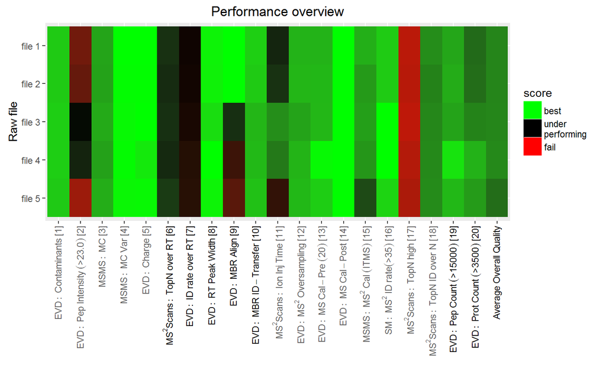

## 1.2 Name Mapping

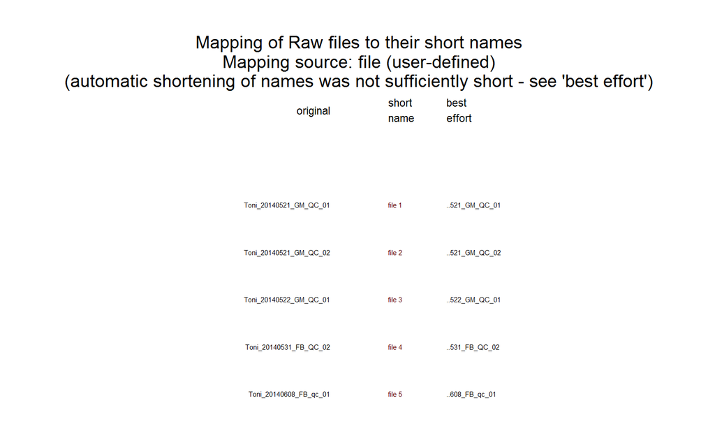

## 1.3 Metrics

### 1.3.1 PAR: parameters

?

MaxQuant parameters, extracted from parameters.txt (abbreviated as ‘PAR’), summarizes the settings used for the MaxQuant analysis. Key parameters are MaxQuant version, Re-quantify, Match-between-runs and mass search tolerances. A list of protein database files is also provided, allowing to track database completeness and database version information (if given in the filename).

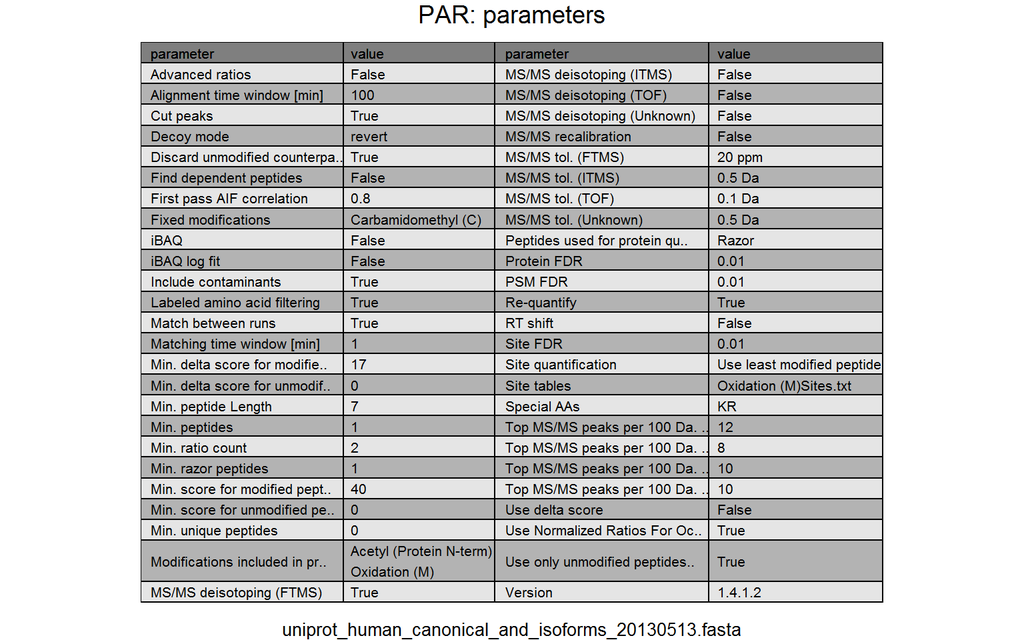

back to top

### 1.3.2 PG: PCA of ‘raw intensity’

**(excludes contaminants)**

?

Principal components plots of experimental groups (as defined during MaxQuant configuration).

This plot is shown only if more than one group was defined. If LFQ was activated in MaxQuant, an additional PCA plot for LFQ intensities is shown. Similarly, if iTRAQ/TMT reporter intensities are detected.

Heatmap score: none (since data source proteinGroups.txt is not related 1:1 to Raw files)

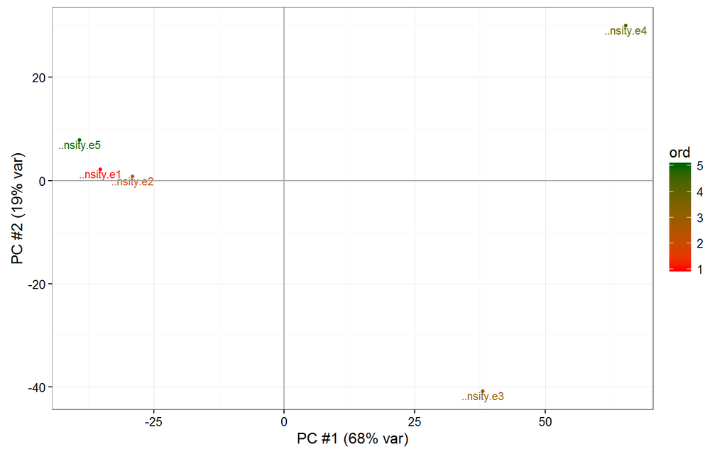

### 1.3.3 PG: PCA of ‘lfq intensity’

**(excludes contaminants)**

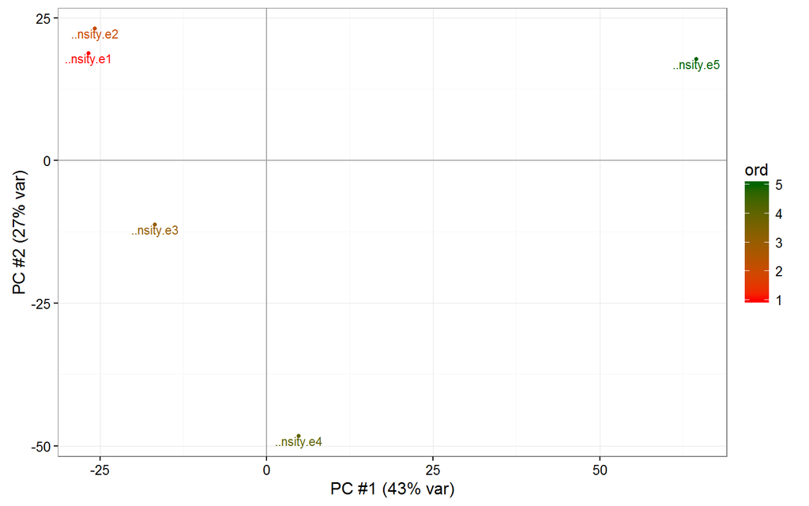

back to top

### 1.3.4 EVD: Top5 Contaminants per Raw file

?

PTXQC will explicitly show the five most abundant external protein contaminants (as detected via MaxQuant’s contaminants FASTA file) by Raw file, and summarize the remaining contaminants as ‘other’. This allows to track down which proteins exactly contaminate your sample. Low contamination is obviously better. Transparency indicates the average peptide intensity in each Raw file. It is not unusual to see samples with low sample content to have higher contamination.

Heatmap score [EVD: Contaminants]: as fraction of summed intensity - 0 = sample full of contaminants - 1 = no contaminants

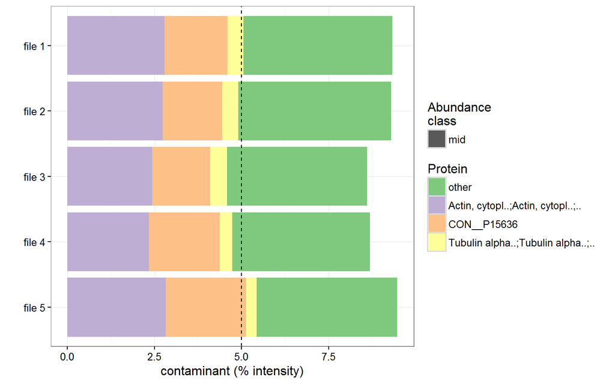

back to top

### 1.3.5 PG: Contaminants

?

User defined contaminant search (usually used for Mycoplasma detection, but can be used for an arbitrary (set of) proteins.

Two abundance measures are computed per Raw file: - fraction of intensity (used for score) - fraction of spectral counts (as comparison for user)

An additional plot with peptide score distributions will be shown if the threshold was reached (i.e. suspected contamination). This allows to decide if the contamination is true, i.e. achieves good MS/MS Andromeda scores (requires a recent MQ version).

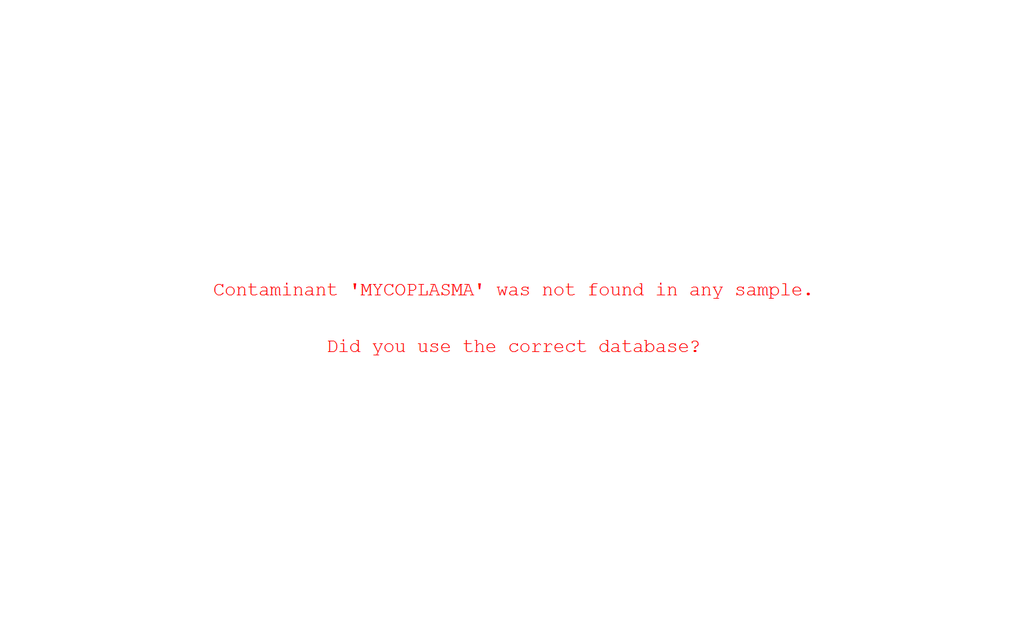

back to top

### 1.3.6 EVD: peptide intensity distribution

**RSD 3.2% (expected < 5%)**

?

Peptide intensity per Raw file from evidence.txt. Failing to reach the intensity threshold is usually due to unfavorable column conditions, inadequate column loading or ionization issues. If the study is not a dilution series or pulsed SILAC experiment, we would expect every condition to have about the same median log-intensity (of 2<sup>23.0</sup>). The relative standard deviation (RSD) gives an indication about reproducibility across files and should be below 5pc.

Heatmap score [EVD: Pep Intensity (>23.0)]: Linear scale of the median intensity reaching the threshold, i.e. reaching 2<sup>21</sup> of 2<sup>23</sup> gives score 0.25.

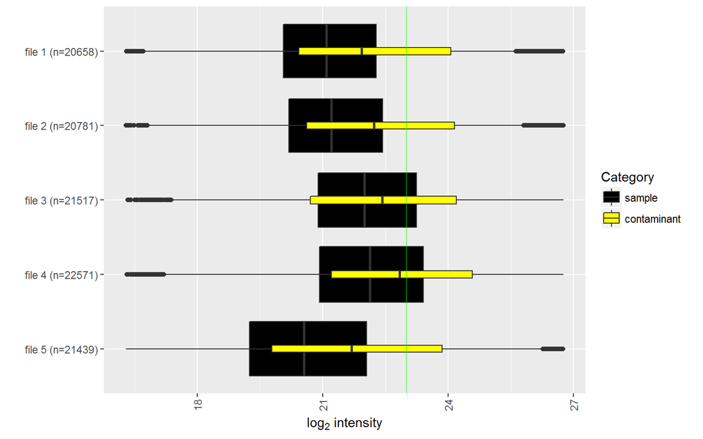

back to top

### 1.3.7 PG: intensity distribution

**RSD 3% (w/o zero int.; expected < 5%)3.2% [high RSD –> few peptides])**

?

Intensity boxplots by experimental groups. Groups are user-defined during MaxQuant configuration. This plot displays a (customizable) threshold line for the desired mean intensity of proteins. Raw files which underperform here, are likely to also suffer from a worse MS/MS id rate and higher contamination due to the lack of total protein loaded/detected. If possible, all Raw files should show a high and consistent amount of total protein. The height of the bar correlates to the number of non-zero protein abundance.

Contaminants are shown as overlayed yellow boxes, whose height corresponds to the number of contaminant proteins. The position of the box is their intensity distribution.

Heatmap score: none (since data source proteinGroups.txt is not related 1:1 to Raw files)

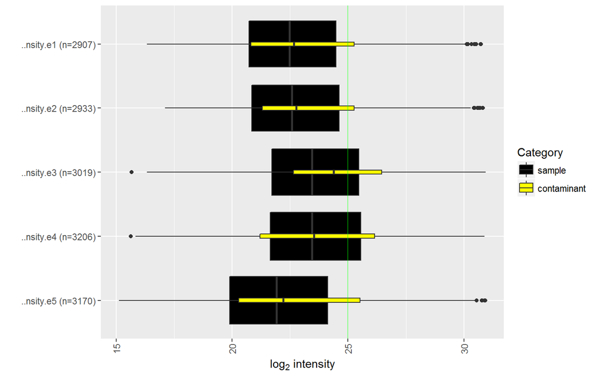

back to top

### 1.3.8 PG: LFQ intensity distribution

**RSD 1.7% (w/o zero int.; expected < 5%)0.5% [high RSD –> few peptides])**

?

Label-free quantification (LFQ) intensity boxplots by experimental groups. Groups are user-defined during MaxQuant configuration. This plot displays a (customizable) threshold line for the desired mean of LFQ intensity of proteins. Raw files which underperform in *Raw* intensity, are likely to show an *increased* mean here, since only high-abundance proteins are recovered and quantifyable by MaxQuant in this Raw file. The remaining proteins are likely to receive an LFQ value of 0 (i.e. do not contribute to the distribution). The height of the bar correlates to the number of non-zero protein abundance.

Contaminants are shown as overlayed yellow boxes, whose height corresponds to the number of contaminant proteins. The position of the box is their intensity distribution.

Heatmap score: none (since data source proteinGroups.txt is not related 1:1 to Raw files)

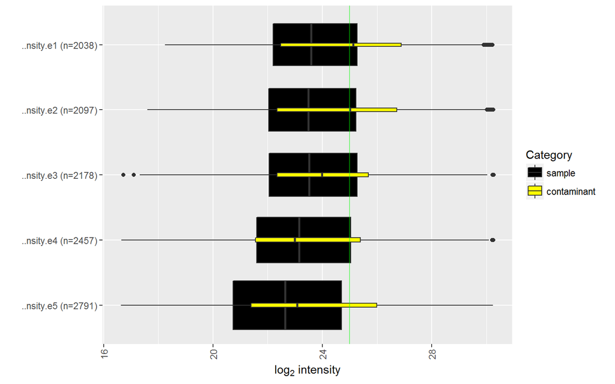

back to top

### 1.3.9 MSMS: Missed cleavages per Raw file

**(excludes contaminants)**

?

Under optimal digestion conditions (high enzyme grade etc.), only few missed cleavages (MC) are expected. In general, increased MC counts also increase the number of peptide signals, thus cluttering the available space and potentially provoking overlapping peptide signals, biasing peptide quantification. Thus, low MC counts should be favored. Interestingly, it has been shown recently that incorporation of peptides with missed cleavages does not negatively influence protein quantification (see http://pubs.acs.org/doi/abs/10.1021/pr500294d ). However this is true only if all samples show the same degree of digestion. High missed cleavage values can indicate for example, either a) failed digestion, b) a high (post-digestion) protein contamination, or c) a sample with high amounts of unspecifically degraded peptides which are not digested by trypsin.

Heatmap score [MSMS: MC]: the fraction (0% - 100%) of fully cleaved peptides per Raw file

Heatmap score [MSMS: MC Var]: each Raw file is scored for its deviation (score: MedianDist) from the ‘average’ digestion state of the current study.

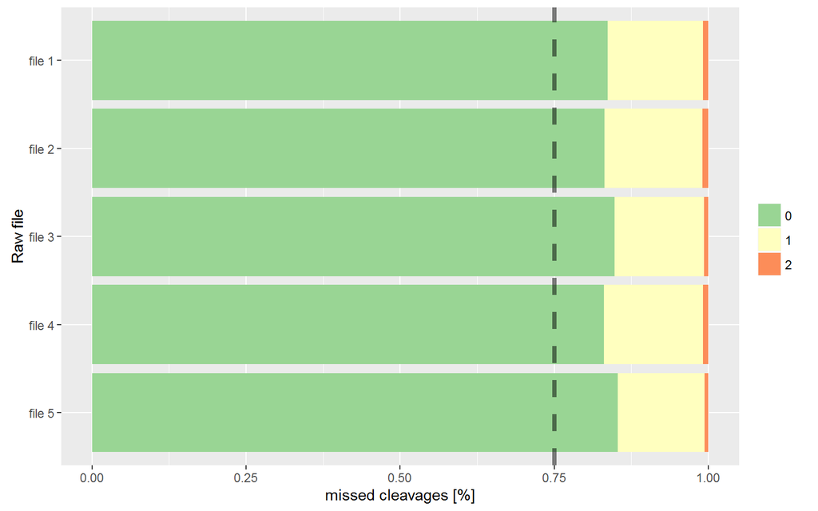

back to top

### 1.3.10 EVD: charge distribution

?

Charge distribution per Raw file. Should be dominated by charge 2 (one N-terminal and one at tryptic C-terminal R or K residue) and have the same fraction in each Raw file. Consistent charge distribution is paramount for comparable 3D-peak intensities across samples.

Heatmap score [EVD: Charge]: Deviation of the charge 2 proportion from a representative Raw file (‘qualMedianDist’ function).

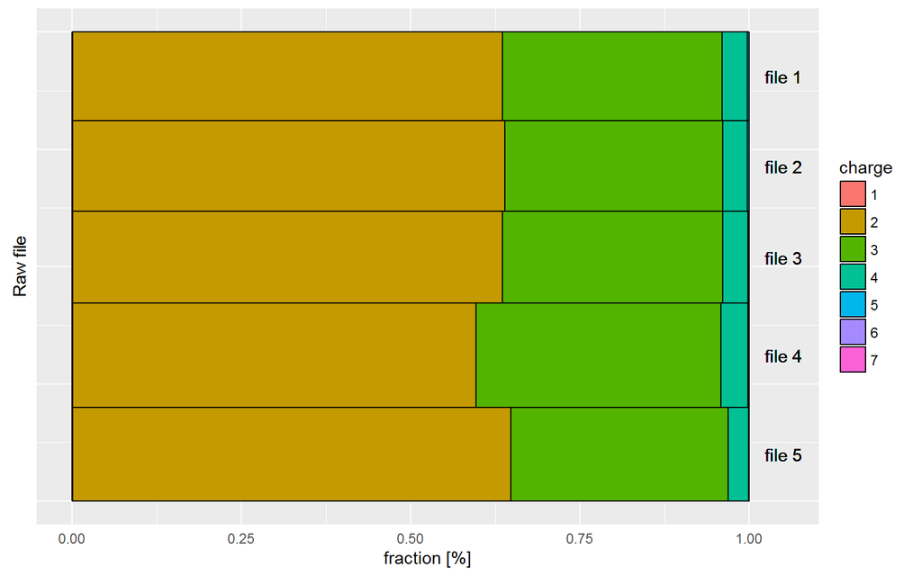

back to top

### 1.3.11 PG: Contaminant per condition

?

External protein contamination should be controlled for, therefore MaxQuant ships with a comprehensive, yet customizable protein contamination database, which is enabled by default. PTXQC generates a contamination plot derived from the proteinGroups (PG) table showing the fraction of total protein intensity attributable to contaminants. The plot employs transparency to indicate the total intensity to delineate a high contamination in high complexity samples from a high contamination in low complexity samples (e.g. from in-gel digestion). Note that this plot is based on experimental groups, and therefore may not correspond 1:1 to Raw files.

Heatmap score: none (since data source proteinGroups.txt is not related 1:1 to Raw files)

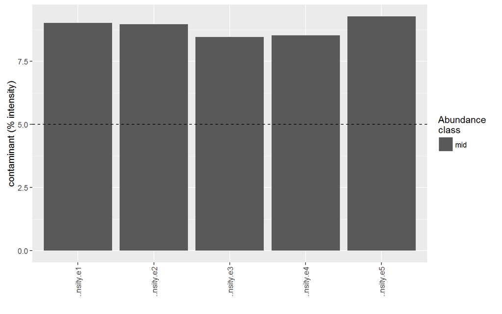

back to top

### 1.3.12 MSMSscans: TopN over RT

?

TopN over retention time. Similar to ID over RT, this metric reflects the complexity of the sample at any point in time. Ideally complexity should be made roughly equal (constant) by choosing a proper (non-linear) LC gradient. See http://www.ncbi.nlm.nih.gov/pubmed/24700534 for details.

Heatmap score [MS<sup>2</sup> Scans: TopN over RT]: Rewards uniform (function Uniform) TopN events over time.

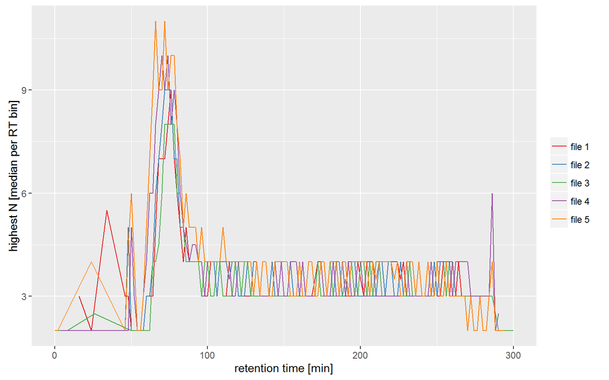

back to top

### 1.3.13 EVD: IDs over RT

?

Judge column occupancy over retention time. Ideally, the LC gradient is chosen such that the number of identifications (here, after FDR filtering) is uniform over time, to ensure consistent instrument duty cycles. Sharp peaks and uneven distribution of identifications over time indicate potential for LC gradient optimization. See http://www.ncbi.nlm.nih.gov/pubmed/24700534 for details.

Heatmap score [EVD: ID rate over RT]: Scored using ‘Uniform’ scoring function, i.e. constant receives good score, extreme shapes are bad.

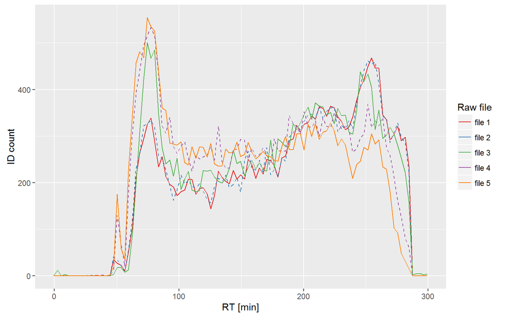

back to top

### 1.3.14 EVD: Peak width over RT

?

One parameter of optimal and reproducible chromatographic separation is the distribution of widths of peptide elution peaks, derived from the evidence table. Ideally, all Raw files show a similar distribution, e.g. to allow for equal conditions during dynamic precursor exclusion, RT alignment or peptide quantification.

Heatmap score [EVD: RT Peak Width]: Scored using BestKS function, i.e. the D statistic of a Kolmogoriv-Smirnoff test.

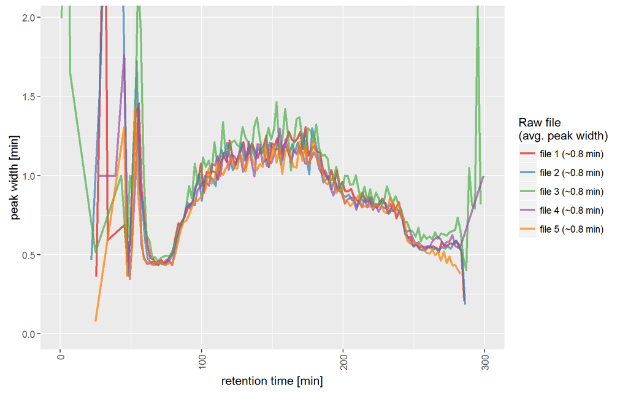

back to top

### 1.3.15 EVD: MBR - alignment

**alignment reference: Toni_20140521_GM_QC_01**

?

MBR Alignment: First of two steps (1=align, 2=transfer) during Match-between-runs. This plot is based purely on real MS/MS ids. Ideally, RTs of identical peptides should be equal (i.e. very small residual RT delta) across Raw files after alignment.

MaxQuants RT correction is shown in blue – it should be well within the alignment search window (20min by default) set during MaxQuant configuration. The resulting residual RT delta after RT alignment (compared to a reference Raw file), is shown as green/red dots. One dot represents one peptide (incl. charge). Every dot (peptide) outside an allowed residual delta RT (1min by default) is colored red. All others are green.

If moving ‘red’ dots to the horizontal zero-line (to make them green) requires large RT shifts, then increasing the alignment search window might help MaxQuant to find a better alignment.

Heatmap score [EVD: MBR Align]: fraction of ‘green’ vs. ‘green+red’ peptides.

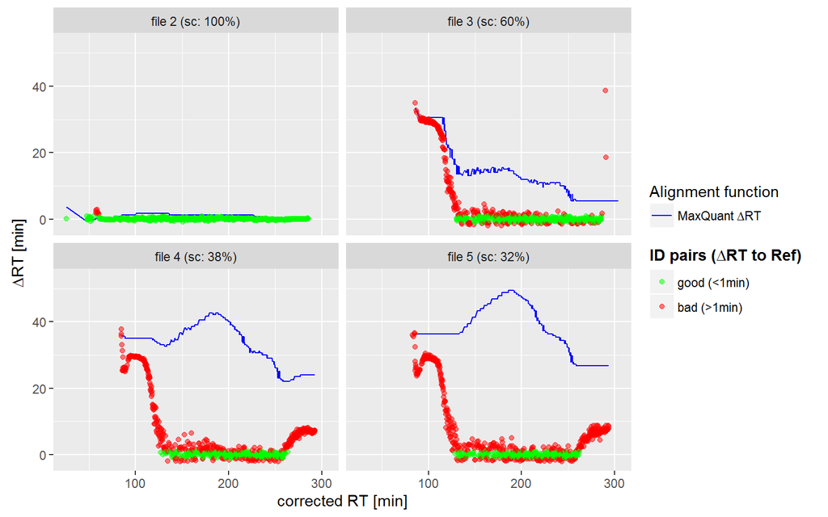

back to top

### 1.3.16 EVD: MBR - ID Transfer

?

MBR Transfer: Last of two steps (1=align, 2=transfer) during Match-between-runs. If MaxQuant only transfers peptide ID’s which are not present in the target file, then each Raw file should not have any duplicates of identical peptides (incl. charge). Sometimes, a single or split 3D-peak gets annotated multiple times, that’s ok. However, the same peptide should not be annotated twice (or more) at vastly different points in RT.

This plot shows three columns: - left: the ‘genuine’ situation (pretending that no MBR was computed) - middle: looking only at transferred IDs - right: combined picture (a mixture of left+middle, usually)

Each peptide falls into three categories (the colors): - single (good, because it has either one genuine OR a transferred ID). - in-group (also good, because all ID’s are very close in RT) - out-group (bad, spread across the RT gradient – should not be possible; a false ID)

Heatmap score [EVD: MBR ID-Transfer]: The fraction of non-out-group peptides (i.e. good peptides) in the middle column. This score is ‘pessimistic’ because if few ID’s were transferred, but all of them are bad, the score is bad, even though the majority of peptides is still ok (because they are genuine). However, in this case MBR provides few (and wrong) additional information, and should be disabled.

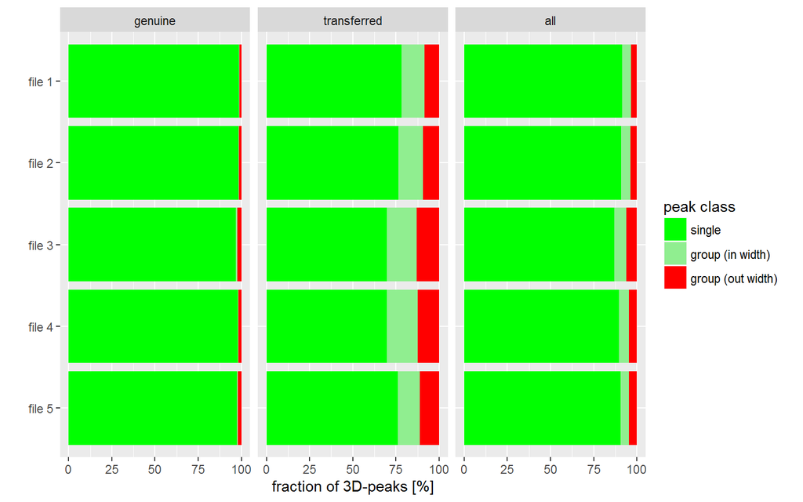

back to top

### 1.3.17 [experimental] EVD: Clustering Tree of Raw files

**by Correlation of Corrected Retention Times**

?

Auxililiary plots – experimental – without scores.

Heatmap score: none.

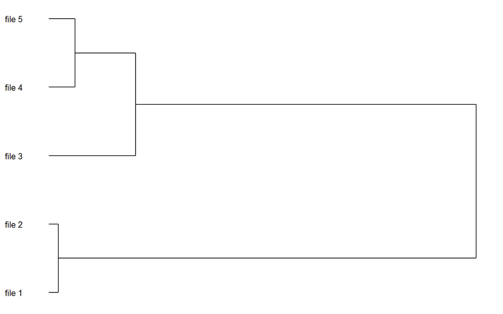

### 1.3.18 EVD: Peptides inferred by MBR

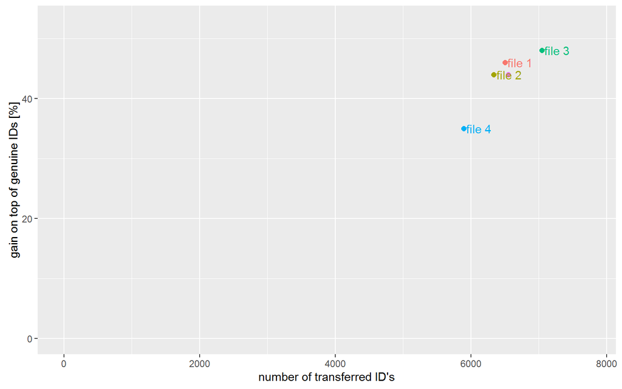

back to top

### 1.3.19 MSMSscans: Ion Injection Time over RT

?

Ion injection time score - should be as low as possible to allow fast cycles. Correlated with peptide intensity. Note that this threshold needs customization depending on the instrument used (e.g., ITMS vs. FTMS).

Heatmap score [MS<sup>2</sup> Scans: Ion Inj Time]: Linear score as fraction of MS/MS below the threshold.

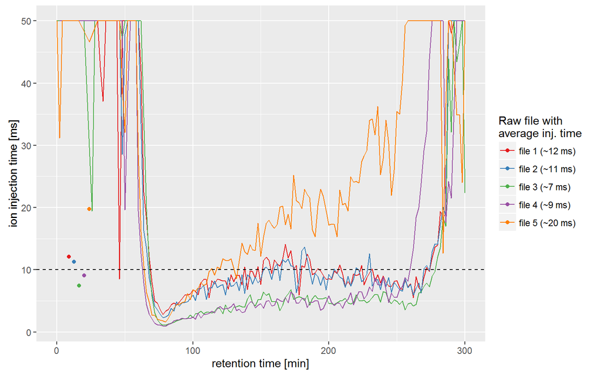

back to top

### 1.3.20 EVD: Oversampling (MS/MS counts per 3D-peak)

?

An oversampled 3D-peak is defined as a peak whose peptide ion (same sequence and same charge state) was identified by at least two distinct MS<sup>2</sup> spectra in the same Raw file. For high complexity samples, oversampling of individual 3D-peaks automatically leads to undersampling or even omission of other 3D-peaks, reducing the number of identified peptides. Oversampling occurs in low-complexity samples or long LC gradients, as well as undersized dynamic exclusion windows for data independent acquisitions.

Heatmap score [EVD: MS<sup>2</sup> Oversampling]: The percentage of non-oversampled 3D-peaks.

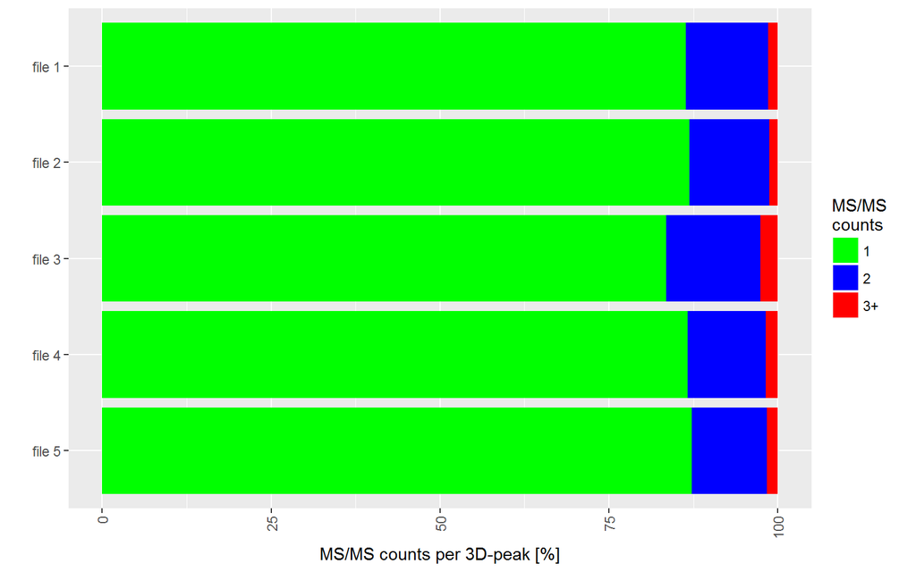

back to top

### 1.3.21 EVD: Uncalibrated mass error

?

Mass accurary before calibration. Outliers are marked as such (‘out-of-search-tol’) using ID rate and standard deviation as additional information (if available). If any Raw file is flagged ‘failed’, increasing MaxQuant’s first-search tolerance (20ppm by default, here: 20.0 ppm) might help to enable successful recalibration. A bug in MaxQuant sometimes leads to excessively high ppm mass errors (>10<sup>4</sup>) reported in the output data. However, this can sometimes be corrected for by re-computing the delta mass error from other data. If this is the case, a warning (‘bugfix applied’) will be shown.

Heatmap score [EVD: MS Cal Pre (20.0)]: the centeredness (function CenteredRef) of uncalibrated masses in relation to the search window size.

```
## Warning: Removed 743 rows containing non-finite values (stat_boxplot).
```

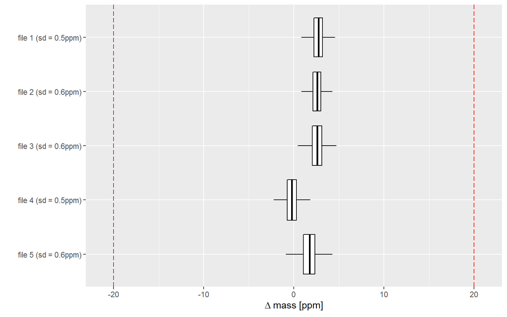

back to top

### 1.3.22 EVD: Calibrated mass error

?

Precursor mass accuracy after calibration. Failed samples from precalibration data are still marked here. Ppm errors should be centered on zero and their spread is expected to be significantly smaller than before calibration.

Heatmap score [EVD: MS Cal-Post]: The variance and centeredness around zero of the calibrated distribution (function GaussDev).

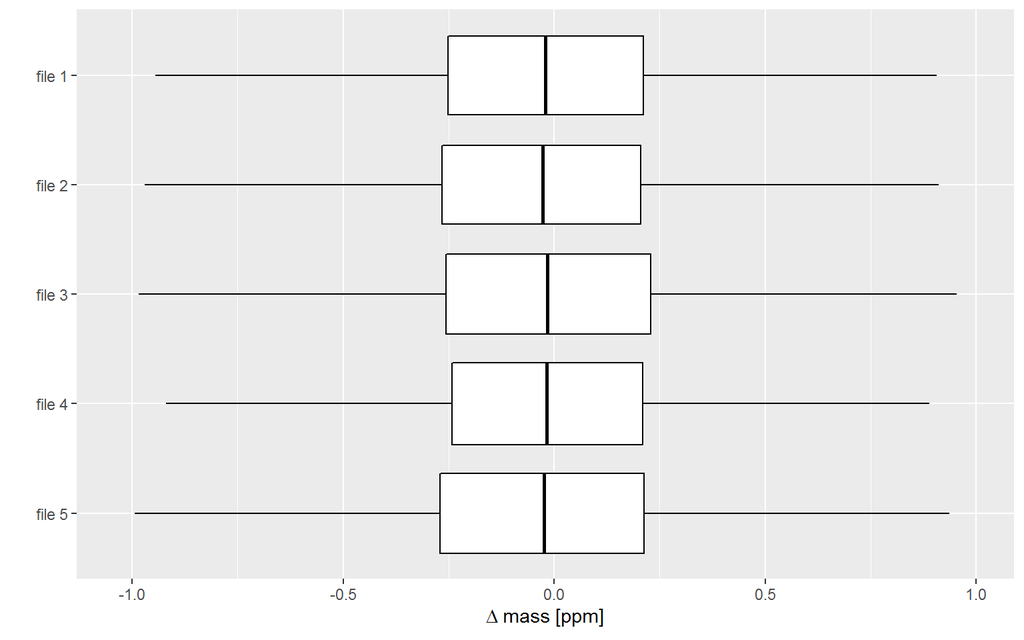

back to top

### 1.3.23 MSMS: Fragment mass errors per Raw file

?

MS/MS decalibration metric. If most of the fragments are within tighter bounds, you can reduce the fragment mass tolerance to obtain more identifications under the same FDR. On the other hand, if the fragment mass errors are not centered on zero (and the distribution is cut by the search tolerance), a recalibration of the instrument should be performed.

Heatmap score [MSMS: MS<sup>2</sup> Cal (Analyzer)]: rewards centeredness around 0 ppm/Da (function Centered).

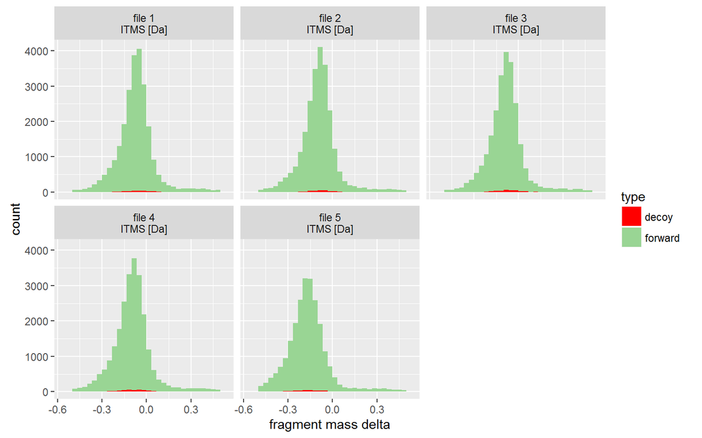

back to top

### 1.3.24 SM: MS/MS identified per Raw file

?

MS/MS identification rate per Raw file from summary.txt (SM). Each Raw file is colored according to its ID rate and categorized into performance bins as ‘bad’, ‘ok’ and ‘great’. Raw files below ‘ok’, are listed separately on the next page of the report for convenient follow-up.

The thresholds for the bins are - bad (<20%) - ok (20-35%) - great (>35%).

Heatmap score [SM: MS<sup>2</sup> IDrate (>35)]: reaches 1 (100pc) if the threshold for ‘great’ is reached or exceeded.

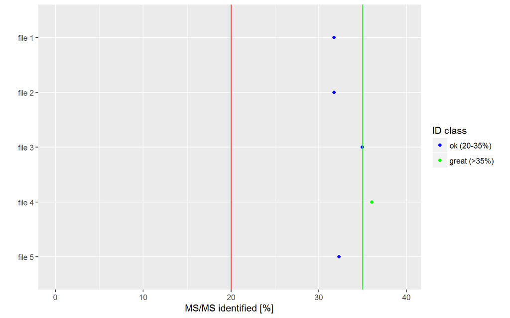

back to top

### 1.3.25 MSMSscans: TopN

?

Reaching TopN on a regular basis indicates that all sections of the LC gradient deliver a sufficient number of peptides to keep the instrument busy. This metric somewhat summarizes ‘TopN over RT’.

Heatmap score [MS<sup>2</sup> Scans: TopN high]: rewards if TopN was reached on a regular basis (function qualHighest)

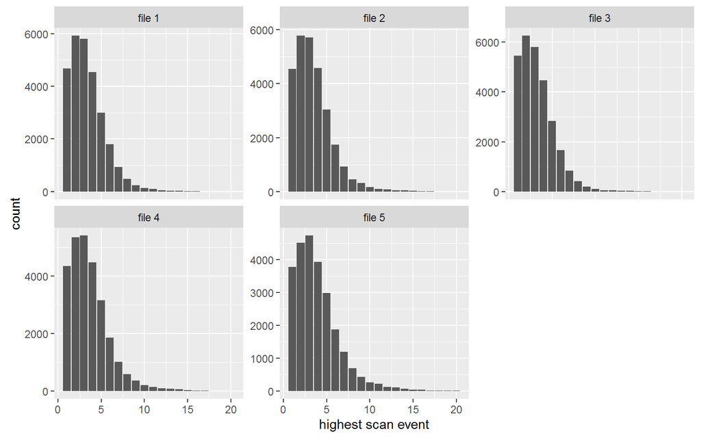

back to top

### 1.3.26 MSMSscans: TopN % identified over N

?

Looking at the identification rates per scan event (i.e. the MS/MS scans after a survey scan) can give hints on how well scheduled precursor peaks could be fragmented and identified. If performance drops for the later MS/MS scans, then the LC peaks are probably not wide enough to deliver enough eluent or the intensity threshold to trigger the MS/MS event should be lowered (if LC peak is already over), or increased (if LC peak is still to weak to collect enough ions).

Heatmap score [MS<sup>2</sup> Scans: TopN ID over N]: Rewards uniform identification performance across all scan events.

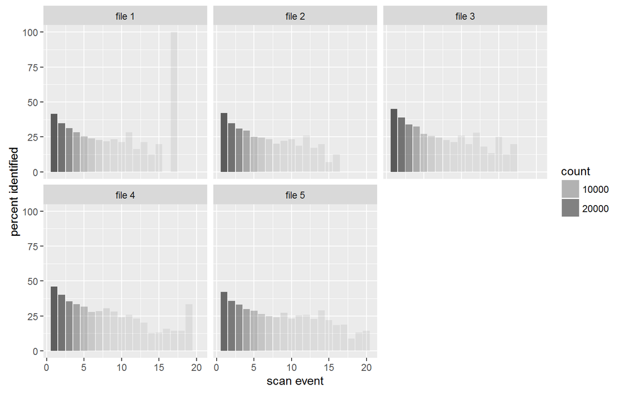

back to top

### 1.3.27 EVD: Peptide ID count

?

Number of peptides (after FDR) per Raw file. A configurable target threshold is indicated as dashed line.

If MBR was enabled, three categories (‘genuine (exclusive)’, ‘genuine + transferred’, ‘transferred (exclusive)’ are shown, so the user can judge the gain that MBR provides. If the gain is low and the MBR scores are bad (see other metrics), MBR should be switched off for the Raw files which are affected (could be a few or all).

Heatmap score [EVD: Pep Count (>15000)]: Reaching the target threshold gives a score of 100pc.

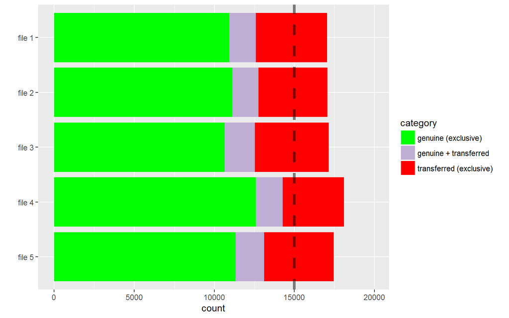

back to top

### 1.3.28 EVD: ProteinGroups count

**MBR gain: +14%**

?

Number of Protein groups (after FDR) per Raw file. A configurable target threshold is indicated as dashed line.

If MBR was enabled, three categories (‘genuine (exclusive)’, ‘genuine + transferred’, ‘transferred (exclusive)’ are shown, so the user can judge the gain that MBR provides. If the gain is low and the MBR scores are bad (see other metrics), MBR should be switched off for the Raw files which are affected (could be a few or all).

Heatmap score [EVD: Prot Count (>3500)]: Reaching the target threshold gives a score of 100pc.

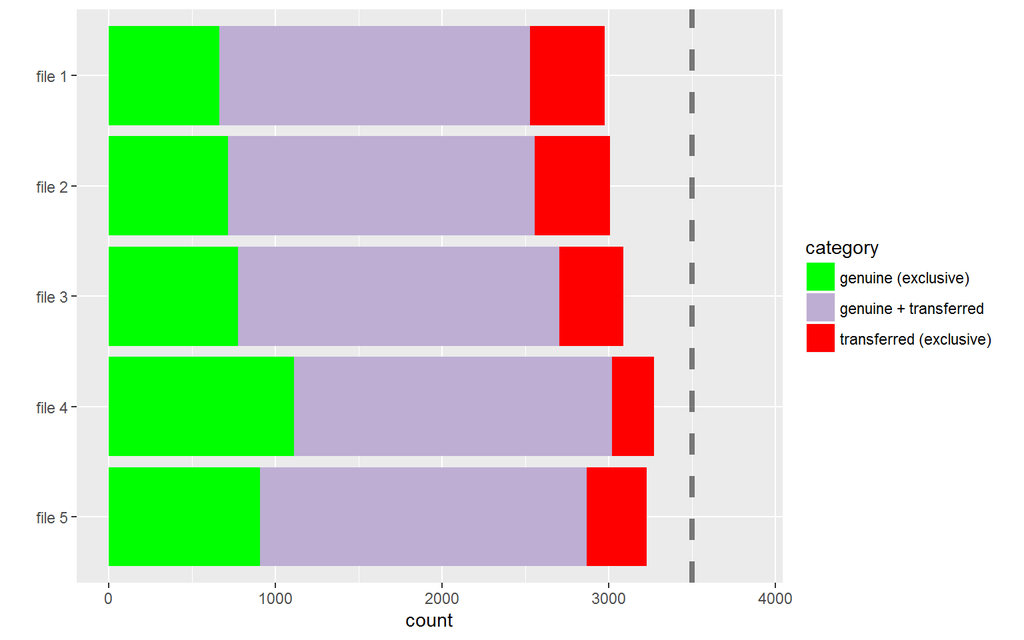

back to top